# A Time Series Analysis on Forecasting Canadian Carrot Prices using SARIMA model

### Intro

This report specifically deals with the forecasting and prediction of Canadian carrot prices for the next twelve observations (i.e., predicting the carrot prices for the next 12 months) using various time series models. Different models have been fitted to the collected data and each model’s limitations and weaknesses will be further evaluated and discussed.

Firstly, to get a rough idea of the observations/data we have already collected, a visual representation of this time series plot is generated as follows:

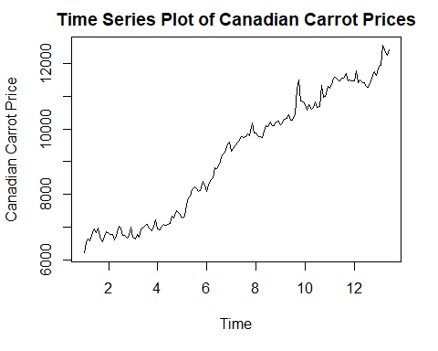

```r
data <- read.csv('Canadian Carrot Prices.csv', header=FALSE)$V2 #get second col only
remove_header = data[-1] #remove header "Canadian Carrot Prices"
numeric_data = as.numeric(levels(remove_header))[remove_header] #convert to numeric data
num_data = length(numeric_data) #150 total observations
ts = ts(numeric_data, freq=12) #convert to time series
plot(ts, ylab = "Canadian Carrot Price", main = "Time Series Plot of Canadian Carrot Prices")
```

(Note that this plot is based on 150 observations).

```r
adf.test(ts)
```

```
    Augmented Dickey-Fuller Test

data:  ts
Dickey-Fuller = -2.5578, Lag order = 5, p-value = 0.344
alternative hypothesis: stationary
```

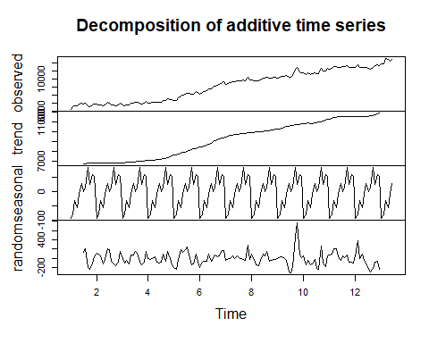

```r
dcmp = decompose(ts)
plot(dcmp)
```

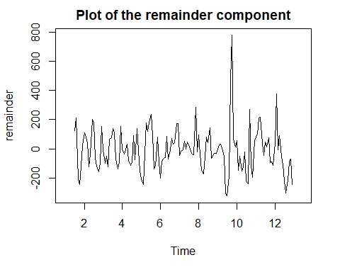

```r
remainder = dcmp$random
plot(remainder, main = "Plot of the remainder component")
```

Based on the classical decomposition, we can conclude that there is indeed somewhat an increasing trend and a strong seasonal pattern. However, the `remainder` (or random) component of the classical decomposition seems somewhat stationary as the mean of the series is now centered and fluctuating accordingly with a more or less consistent variance with some outliers around the 9th year (as I have removed the `trend` and `seasonal` components of the original series). Now, I will attempt to determine the model parameters using PACF and ACF plots, as well as taking suggestion from using the auto.arima() function on this `remainder` series.

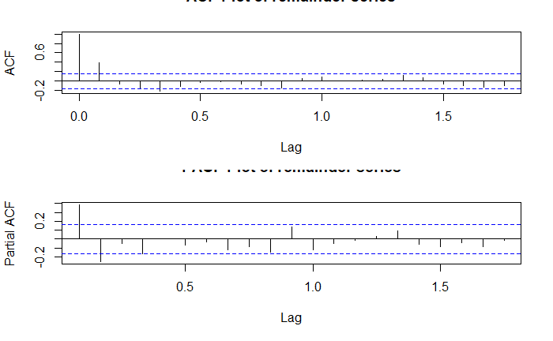

```r
library(astsa)
library(forecast)
par(mfrow=c(2,1))
acf(remainder, na.action= na.pass, main= "ACF Plot of remainder series")
pacf(remainder, na.action= na.pass, main= "PACF Plot of remainder series")
```

```r
auto_remainder = auto.arima(remainder) #auto.arima() on remainder series
```

# Diagnositics for AR(2) model:

```
$fit

Call:
stats::arima(x = xdata, order = c(p, d, q), seasonal = list(order = c(P, D,
    Q), period = S), xreg = xmean, include.mean = FALSE, transform.pars = trans,
    fixed = fixed, optim.control = list(trace = trc, REPORT = 1, reltol = tol))

Coefficients:
         ar1      ar2    xmean
      0.4924  -0.2539  -7.9231
s.e.  0.0828   0.0831  14.9606

sigma^2 estimated as 17904:  log likelihood = -871.67,  aic = 1751.33

$degrees_of_freedom
[1] 135

$ttable
      Estimate      SE t.value p.value
ar1     0.4924  0.0828  5.9458  0.0000
ar2    -0.2539  0.0831 -3.0546  0.0027
xmean  -7.9231 14.9606 -0.5296  0.5973

$AIC
[1] 11.67554

$AICc
[1] 11.67663

$BIC
[1] 11.7536
```

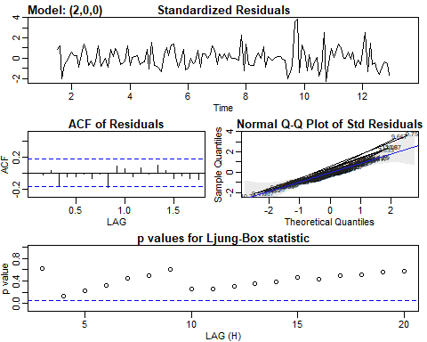

```r
library(astsa)
sarima(remainder, 2,0,0) #AR(2)
```

First, we can see from the ACF plot of the residuals that they are all within the 95% confidence intervals, indicating that there is no correlation between the residuals (suggesting a good fit of the model). The Normal Q-Q plot suggests that there are a few outliers (on both end of the tails), making the normality of the residuals to be slightly violated (but the bulk of the residuals are still following a Normal distribution). All p-values of the Ljung-Box test are all above the 5% confidence level (blue dashed line), indicating that the model has no serial correlation with 95% confidence level. Finally, the AIC value for the AR(2) model is 11.676, AICc is 11.677, and BIC is 11.753 and we will compare these values with our next potential model, the MA(1) model.

Diagnositics for MA(1) model:

```
$fit

Call:
stats::arima(x = xdata, order = c(p, d, q), seasonal = list(order = c(P, D,
    Q), period = S), xreg = xmean, include.mean = FALSE, transform.pars = trans,
    fixed = fixed, optim.control = list(trace = trc, REPORT = 1, reltol = tol))

Coefficients:
         ma1    xmean
      0.5152  -8.1218
s.e.  0.0780  17.2728

sigma^2 estimated as 18019:  log likelihood = -872.11,  aic = 1750.22

$degrees_of_freedom
[1] 136

$ttable
      Estimate      SE t.value p.value
ma1     0.5152  0.0780  6.6037   0.000
xmean  -8.1218 17.2728 -0.4702   0.639

$AIC
[1] 11.66813

$AICc
[1] 11.66868

$BIC
[1] 11.72668
```

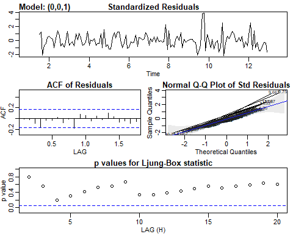

```r
sarima(remainder, 0,0,1) #MA(1)
```

Now, we can see from the ACF plot of the residuals for the MA(1) model that they are all within the 95% confidence intervals too, indicating that there is no correlation between the residuals (suggesting a good fit of the model). The Normal Q-Q plot suggests that there are a few extreme outliers like the AR(2) model (on both end of the tails), making the normality of the residuals to be slightly violated (but the bulk of the residuals are still following a Normal distribution). All p-values of the Ljung-Box test are all above the 5% confidence level (blue dashed line) as well, indicating that the model has no serial correlation with a 95% confidence level. Finally, the AIC value for the MA(1) model is 11.668, AICc is 11.669, and BIC is 11.727, which is all better than that of the AR(2) model, making this model a more preferable choice out of the two.